# 1. SHELL SCRIPTING

# Literature

1. Arnold Robbins, Nelson H. F. Beebe "Classic Shell Scripting", May 2005, ISBN: 9780596555269
2. GNU/Linux - Shell

# 0. Preliminaries

*ChatGPT:*  
Yes, shell scripting is essential for many DevOps positions. Here’s why shell scripting is crucial in the DevOps field, along with some specific scenarios where it is particularly beneficial:

**Why Shell Scripting is Important for DevOps**

1. **Automation of Routine Tasks**:
   - DevOps involves a lot of repetitive tasks like deployments, backups, log rotation, and monitoring. Shell scripts can automate these tasks, saving time and reducing human error.
2. **System Administration**:
   - Shell scripts are used to manage servers, including starting/stopping services, managing system configurations, and handling user permissions.
3. **CI/CD Pipelines**:
   - Continuous Integration and Continuous Deployment pipelines often involve a series of shell commands to build, test, and deploy applications. Shell scripting helps in orchestrating these commands efficiently.
4. **Configuration Management**:
   - Tools like Ansible, Puppet, and Chef often utilize shell scripting to perform low-level system configuration tasks.
5. **Environment Setup**:
   - Setting up development, testing, and production environments often requires running a series of shell commands to install software, configure settings, and ensure that the environment is ready for use.
6. **Monitoring and Logging**:
   - Shell scripts can be used to monitor system performance, collect logs, and alert the team when certain thresholds are exceeded.

**Specific Scenarios Where Shell Scripting is Used in DevOps**

1. **Deployments**:
   - Automating the deployment of applications to various environments (development, staging, production) often involves shell scripts that handle tasks such as copying files, restarting services, and running database migrations.
2. **System Health Checks**:
   - Scripts that check the status of services, disk space usage, memory utilization, and other system metrics. These scripts can be run at regular intervals and alert the team if something goes wrong.
3. **Backup and Restore**:
   - Automating the process of backing up databases and important files, and restoring them when needed. Shell scripts can schedule these tasks to run at specific times using cron jobs.
4. **Log Management**:
   - Rotating, compressing, and archiving log files to ensure that logs do not consume too much disk space. Shell scripts can also parse logs and extract relevant information for further analysis.
5. **Environment Variables and Configuration Files**:
   - Managing environment variables and configuration files for different environments. Shell scripts can be used to ensure that the correct configurations are applied in each environment.

**Integration with Other DevOps Tools**

While shell scripting is fundamental, it often works in tandem with other DevOps tools:

- **Docker**: Shell scripts can be used to build, tag, and push Docker images, as well as to run containers.
- **Kubernetes**: Shell scripts can interact with `kubectl` to manage Kubernetes clusters and deployments.
- **Jenkins**: Shell scripting is frequently used within Jenkins pipelines to perform build and deployment steps.
- **Terraform**: While Terraform uses its own language, shell scripts can be used for provisioning resources that Terraform does not directly support.

**Conclusion**

Shell scripting is a vital skill for DevOps professionals because it enables the automation of a wide range of tasks, from system administration to deployment and monitoring. While other scripting and programming languages (like Python) are also valuable, shell scripting is often the quickest and most direct way to interact with the Unix/Linux operating systems and DevOps tools. Learning shell scripting will make you more effective in a DevOps role by enabling you to automate and streamline your workflows.

# 1.0 Commands handout

| command | description |
| --- | --- |
| **1. Get location string** |  |
| `readlink -f` | print resolved symbolic links or canonical file names; `-f` canonicalize by following every symlink in every component of the given name recursively; all but the last component must exist |
| `dirname` | strip last component from file name |
| `basename` | strip directory and suffix from filenames |
| **2. Command Options** |  |
| `<command> --` | two dashes should be used to signify the end of options |
| **3. Run the script** |  |
| `#!/bin/bash -` | The bare option `–` says that there are no more shell options; this is a security feature |
| **4. Output manipulation commands** |  |
| `echo` | display a line of text; has portability problems |
| `printf` | format and print data; best alternative to `echo` |
| `tr` | translate or delete characters |
| `stty` | change and print terminal line settings |
| `stty -echo` | turn of echoing; `stty echo` returns it |
| **5. Special files** |  |
| `/dev/null` | bytes neverland |
| `/dev/tty` | a special file that represents the controlling terminal for the current process |

# 1.1 Background

# 1.2 Software Tools Principles

1. Do one thing well
2. Process lines of text, not binary
3. Use regular expressions (BRE, ERE)
4. Default to standard I/O
5. Don't be chatty
6. Generate the same output format accepted as input
7. Let someone else do the hard part
8. Detour to build specialized tools

# 1.3 Getting Started

Shell scripts are used most often

- for system administration tasks, or
- for combining existing programs to accomplish some small, specific job.

Once you’ve figured out how to get the job done, you can bundle up the commands into a separate program, or **script**, which you can then run directly. What’s more, if it’s useful, other people can make use of the program, treating it as a *black box*, a program that gets a job done, without their having to know how it does so.

Examples of scripting languages include awk, Perl, Python, Ruby, and the shell.

The reasons to use a shell script are:

- **Simplicity**
  - The shell is a high-level language; you can express complex operations clearly and simply using it.
- **Portability**
  - By using just POSIX-specified features, you have a good chance of being able to move your script, unchanged, to different kinds of systems.
- **Ease of development**
  - You can often write a powerful, useful script in little time.

## A Simple Script

### Count users

```
$ cat > nusers      # Create the file, copy terminal input with cat
who | wc -l         # Program text
^D                  # Ctrl-D is end-of-file
$ chmod +x nusers   # Make it executable
$ ./nusers          # Do a test run
6                   # Output is what we expect
```

```bash
cd /tmp

cat > nusers << 'text'
who | wc -l
text

# run in a subshell
chmod +x nusers
./nusers
```

```
9
```

This shows the typical development cycle for small one- or two-line shell scripts:

- first, you experiment directly at the command line.
- Then, once you’ve figured out the proper incantations to do what you want, you put them into a separate script and make the script executable.

You can then use that script directly from now on.

## Self-Contained Scripts

### `#!`

When the shell runs a program, it asks the Unix kernel to start a new process and run the given program in that process. The kernel knows how to do this for compiled programs.

When the shell asks the kernel to run the shell script, the kernel will fail to do so, returning a “not executable format file” error. The shell, upon receiving this error, proceeds to start a new copy of `/bin/sh` (the standard shell) to run the program.

The “fall back to /bin/sh” mechanism is great when there’s only one shell. However, because current Unix systems have multiple shells, there needs to be a way to tell the Unix kernel which shell to use when running a particular shell script. In fact, it helps to have a general mechanism that makes it possible to directly invoke any programming language interpreter, not just a command shell. This is done via a special first line in the script file—one that begins with the two characters `#!`.

When the first two characters of a file are `#!`, the kernel scans the rest of the line for the full pathname of an interpreter to use to run the program. (Any intervening whitespace is skipped.) The kernel also scans for a single option to be passed to that interpreter. The kernel invokes the interpreter with the given option, along with the rest of the command line. For example, assume a csh script named `/usr/ucb/whizprog`, with this first line:

```
#! /bin/csh -f
```

Furthermore, assume that `/usr/ucb` is included in the shell’s search path. A user might type the command

```
whizprog -q /dev/tty01
```

The kernel interprets the `#!` line and invokes csh as follows:

```
/bin/csh -f /usr/ucb/whizprog -q /dev/tty01
```

This mechanism makes it easy to invoke *any* interpreted language. For example, it is a good way to invoke a standalone awk program:

```
#! /bin/awk -f
awk program here
```

### Remember

1. On modern systems, the maximum length of the `#!` line varies from `63` to `1024` characters. Try to keep it less than 64 characters.
2. On some systems, the “rest of the command line” that is passed to the interpreter includes the full pathname of the command. On others, it does not; the command line as entered is passed to the program. Thus, scripts that look at the command-line arguments cannot portably depend on the full pathname being present.
3. Don’t put any trailing whitespace after an option, if present. It will get passed along to the invoked program along with the option.
4. You have to know the full pathname to the interpreter to be run. This can prevent cross-vendor portability, since different vendors put things in different places (e.g., `/bin/awk` versus `/usr/bin/awk`).
5. On antique systems that don’t have `#!` interpretation in the kernel, some shells will do it themselves, and they may be picky about the presence or absence of whitespace characters between the `#!` and the name of the interpreter.

#### Some considerations

- to 2. To make the script portable and ensure it always finds the correct directory, you can resolve the full path to the script using `readlink -f` (or an equivalent) to handle different invocation styles:

```
#!/bin/bash

# Get the full path of the script
script_path=$(readlink -f "$0")
script_dir=$(dirname "$script_path")

# Path to the configuration file
config_file="$script_dir/config.txt"

# Print the paths for demonstration
echo "Script full path: $script_path"
echo "Script directory: $script_dir"
echo "Configuration file: $config_file"
```

```bash
a=$(readlink -f .)
echo $a
dirname $a
basename $a
```

```
/home/commi/Yandex.Disk/it_learning/06_devops/01_shell_scripting
/home/commi/Yandex.Disk/it_learning/06_devops
01_shell_scripting
```

- to 4. On Debian these are symlinks to `/usr/bin/mawk`:

```bash
ls -l /bin/awk
ls -l /usr/bin/awk
ls -l /etc/alternatives/awk
ls -l /usr/bin/mawk
```

```
lrwxrwxrwx 1 root root 21 Jun 17  2022 /bin/awk -> /etc/alternatives/awk*
lrwxrwxrwx 1 root root 21 Jun 17  2022 /usr/bin/awk -> /etc/alternatives/awk*
lrwxrwxrwx 1 root root 13 Jun 17  2022 /etc/alternatives/awk -> /usr/bin/mawk*
-rwxr-xr-x 1 root root 158376 Jun 17  2022 /usr/bin/mawk*
```

### Revised example script

```bash
cd /tmp

cat > nusers << 'text'
#!/bin/bash -
who | wc -l
text
chmod +x nusers

# run in a subshell
./nusers
```

```
10
```

# 1.4 Basic Shell Constructs

## Commands and Arguments

The shell recognizes three fundamental kinds of commands:

- built-in commands,
- shell functions, and
- external commands.
- **Built-in commands** are just that: commands that the shell itself executes. Some commands are built-in from necessity, such as cd to change the directory, or read to get input from the user (or a file) into a shell variable. Other commands are often built into the shell for efficiency. Most typically, these include the test command (described later in “The test Command” [6.2.4]), which is heavily used in shell scripting, and I/O commands such as echo or printf.
- **Shell functions** are self-contained chunks of code, written in the shell language, that are invoked in the same way as a command is. We delay discussion of them until “Functions” [6.5]. At this point, it’s enough to know that they’re invoked, and they act, just like regular commands.
- **External commands** are those that the shell runs by creating a separate process (subshell?). The basic steps are:
  1. Create a new process. This process starts out as a copy of the shell.
  2. In the new process, search the directories listed in the `PATH` variable for the given command. `/bin:/usr/bin:/usr/X11R6/bin:/usr/local/bin` might be a typical value of `PATH`. (The path search is skipped when a command name contains a slash character, `/`.)
  3. In the new process, execute the found program by replacing the running shell program with the new program.
  4. When the program finishes, the original shell continues by reading the next command from the terminal, or by running the next command in the script.

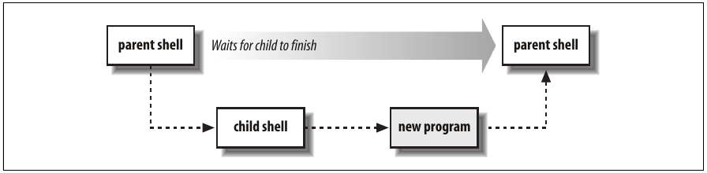

*Program execution (in a subshell)*

*ChatGPT:*

Key differences between executing an external command and using the `source` command to run a script

| **Aspect** | **External Command** | **`source ./script.sh`** |
| --- | --- | --- |
| **Process Creation** | Creates a new process. | No new process is created. |
| **Execution Context** | Runs in a new process. | Runs in the current shell context. |
| **Environment Variable Changes** | Changes do not persist in the parent shell. | Changes persist in the current shell. |
| **Performance** | May have overhead due to process creation. | Faster, as it avoids creating a new process. |
| **Typical Use Case** | Executing standalone programs or utilities. | Running scripts that modify the current shell environment (e.g., setting environment variables). |
| **Path Search** | Searches directories in PATH for the command. | Not applicable, as the script is specified directly. |
| **Continuation** | Original shell waits for the new process to finish, then continues. | Shell continues immediately after sourcing the script. |

When to run scripts in a subshell versus sourcing them

| **Scenario** | **Run in Subshell** | **Source in Current Shell** |
| --- | --- | --- |
| **Isolation Required** | Yes | No |
| **No Persistent Changes Needed** | Yes | No |
| **Independent Execution** | Yes | No |
| **Environment Modifications Needed** | No | Yes |
| **Profile/Setup Scripts** | No | Yes |
| **Interactive Environment Adjustments** | No | Yes |
| **Performance Considerations** | Generally acceptable for short scripts | More efficient for frequent changes |

In conclusion, while running scripts in a subshell is common and appropriate for standalone tasks, sourcing scripts is necessary when you need to modify the current shell's environment. Choose the approach that best fits the needs of your specific task.

## Variables

Shell variables hold string values, and there is also no limit on the number of characters that they may hold. (The Bourne shell was one of the few early Unix programs to follow a “no arbitrary limits” design principle.)

**Variables** are assigned values by writing the variable name, immediately followed by an `=` character, and the new value, without any intervening spaces. Shell variable values are retrieved by prefixing the variable’s name with a `$` character.

Use quotes when assigning a literal value that contains spaces:

```bash
first=isaac middle=bashevis last=singer  # Multiple assignments allowed on one line
fullname="isaac bashevis singer"         # Use quotes for whitespace in value
oldname=$fullname                        # Quotes not needed to preserve spaces in value
```

As shown in the previous example, double quotes aren’t necessary around the value of one variable being used as the new value of a second variable. Using them, though, doesn’t hurt either, and is necessary when concatenating variables:

```bash
fullname="$first $middle $last"  # Double quotes required here
echo $fullname
```

```
isaac bashevis singer
```

## Simple Output with echo

We just saw the `echo` command for printing out the value of `fullname`, and you’ve probably used it at the command line. `echo`’s job is to produce output, either for prompting or to generate data for further processing.

The original `echo` command simply printed its arguments back to standard output, with each one separated from the next by a single space and terminated with a newline:

```bash
echo Now is the time for all good men
echo to come to the aid of their country.
```

```
Now is the time for all good men
to come to the aid of their country.
```

Unfortunately, over time, different versions of `echo` developed. The BSD version accepted a first argument of `–n`, which would make it omit the trailing newline. For example (the underscore represents the terminal’s cursor):

```
$ echo -n "Enter your name: "   # Print prompt
Enter your name: _              # Enter data
```

> *NOTE*: your shell may have its own version of `echo`, which usually supersedes the version described here. Please refer to your shell's documentation for details about the options it supports

```bash
echo $SHELL
help echo
```

```
/bin/bash
echo: echo [-neE] [arg ...]
    Write arguments to the standard output.

    Display the ARGs, separated by a single space character and followed by a
    newline, on the standard output.

    Options:
      -n	do not append a newline
      -e	enable interpretation of the following backslash escapes
      -E	explicitly suppress interpretation of backslash escapes

    `echo' interprets the following backslash-escaped characters:
      \a	alert (bell)
      \b	backspace
      \c	suppress further output
      \e	escape character
      \E	escape character
      \f	form feed
      \n	new line
      \r	carriage return
      \t	horizontal tab
      \v	vertical tab
      \\	backslash
      \0nnn	the character whose ASCII code is NNN (octal).  NNN can be
    		0 to 3 octal digits
      \xHH	the eight-bit character whose value is HH (hexadecimal).  HH
    		can be one or two hex digits
      \uHHHH	the Unicode character whose value is the hexadecimal value HHHH.
    		HHHH can be one to four hex digits.
      \UHHHHHHHH the Unicode character whose value is the hexadecimal value
    		HHHHHHHH. HHHHHHHH can be one to eight hex digits.

    Exit Status:
    Returns success unless a write error occurs.
```

## `printf`

This command is more flexible than `echo`, but at the cost of some added complexity.

```bash
man echo | grep "NOTE" | sed -n '2p'
```

```
       NOTE:  printf(1) is a preferred alternative, which does not have issues
```

In effect, `echo` could be used portably only if it was used in the simplest fashion.

The `printf` command is modeled after the `printf( )` library routine from the C library and can output a simple string just like the `echo` command.

```bash
printf 'Rot Front!\n'  # use single quotes
printf "Rot Front!\n"
```

```
Rot Front!
bash: !\n: event not found
```

The main difference that you will notice immediately is that, unlike `echo`, `printf` does not automatically supply a newline. You must specify it explicitly as `\n`. The full syntax of the `printf` command has two parts:

```
printf format-string [arguments ...]
```

```bash
printf 'I use "%s" as my default shell\n' $BASH
```

```
I use "/usr/bin/bash" as my default shell
```

## Basic I/O Redirection

Standard I/O is perhaps the most fundamental concept in the Software Tools philosophy. The idea is that programs should have

- a data source,
- a data sink (where data goes), and
- a place to report problems.

These are referred to by the names

- **standard input**,
- **standard output**, and
- **standard error**, respectively.

A program should neither know, nor care, what kind of device lies behind its input and outputs: disk files, terminals, tape drives, network connections, or even another running program! A program can expect these standard places to be already open and ready to use when it starts up.

Many, if not most, Unix programs follow this design. By default, they read standard input, write standard output, and send error messages to standard error. Such programs are called **filters**, for reasons that will become clear shortly. The default for standard input, standard output, and standard error is the terminal. This can be seen with `cat`:

```
$ cat
now is the time      # With no arguments, read standard input, write standard output
now is the time      # Typed by the user
for all good men     # Echoed back by cat
for all good men
^D                   # Ctrl-D, End of file
```

When you log in, Unix arranges the default place for standard input, output, and error to be your terminal. I/O redirection is the process by which you, at the terminal interactively, or from within a shell script, then arrange to change the places from which input comes or to which output goes.

### Redirection and pipelines

See GNU/Linux - Shell

Although `<` and `>` connect input and output to files, a pipeline hooks together two or more running programs. The standard output of the first program becomes the standard input of the second one. In favorable cases,

> pipelines can run as much as ten times faster than similar code using temporary files.

Most of this book is about learning how to hook together the various tools into pipelines of increasing complexity and power. For example:

```
tr -d '\r' < dos-file.txt | sort > unix-file.txt
```

This pipeline removes carriage-return characters from the input file, and then sorts the data, sending the resulting output to the destination file.

### `stty`

The other special file is `/dev/tty`. When a program opens this file, Unix automatically redirects it to the real terminal (physical console or serial port, or pseudoterminal for network and windowed logins) associated with the program. This is particularly useful for reading input that must come from a human, such as a password. It is also useful, although less so, for generating error messages:

```
printf "Enter new password: "   # Prompt for input
stty -echo                      # Turn off echoing of typed characters
read pass < /dev/tty            # Read password
printf "Enter again: "          # Prompt again
read pass2 < /dev/tty           # Read again for verification
stty echo                       # Don't forget to turn echoing back on
...
```

The `stty` (set tty) command controls various settings of your terminal (or window).

> `stty` is possibly the most baroque and complicated Unix command in existence. See the stty(1) manpage for the gory details.

The `–echo` option turns off the automatic printing (echoing) of every character you type; `stty echo` restores it.